# Estadística para el Análisis Sociológico 2

Práctica Calificada 2

Joaquín Pérez Guerra (2018 0335)

2022-06-03

# 1A - Perú: Computadoras de escritorio (PC) para uso pedagógico en colegios de primaria entre ámbito urbano y rural, 2021.

Tabla 1A. Perú: Computadoras de Escritorio (PC) para uso pedagógico en primaria, por ámbito, 2021 (%)

| Número de equipos | Ámbito Urbano | Ámbito Rural |
| --- | --- | --- |
| Ningún equipo | 32.7 | 58.4 |
| Menos de 20 equipos | 39.9 | 33.9 |
| de 20 a 59 equipos | 25.5 | 7.7 |
| De 60 a 100 equipos | 1.9 | 0.0 |
| Más de 100 equipos | 0.1 | 0.0 |

* Fuente: ENEDU 2021 (INEI). Tabla de elaboración propia

**Análisis:** En líneas generales, encontramos que en el área urbana hay mayor porcentaje de escuelas primarias que cuentan con equipos que en el área rural. Por ejemplo, mientras en el área rural el porcentaje de escuelas que tienen ‘De 60 a 100 equipos’ y ‘Más de 100 equipos’ es 0%, en el área urbana es de 1.9% y 0.1%, respectivamente. Igualmente, para las categorías ‘Menos de 20 equipos’ y ‘De 20 a 59 equipos’, el porcentaje de colegios urbanos de primaria que se encuentran en estas categorías superan a los colegios rurales de primaria. Por último , mientras en los colegios de área rural de primaria la mayor concentración de casos está en la categoría ‘Ningún equipo’ (58.4%), en los colegios de área urbana de primaria la mayor concentración de casos está en la categoría ‘Menos de 20 equipos’ (39.9%). En ese sentido, podríamos concluir que los colegios de primaria del ámbito urbano están mejor equipados que los del ámbito rural.

# 1B - Perú: Computadoras portátiles (laptops) operativas en el aula de clases en colegios de primaria entre el ámbito urbano y rural, 2021 (%).

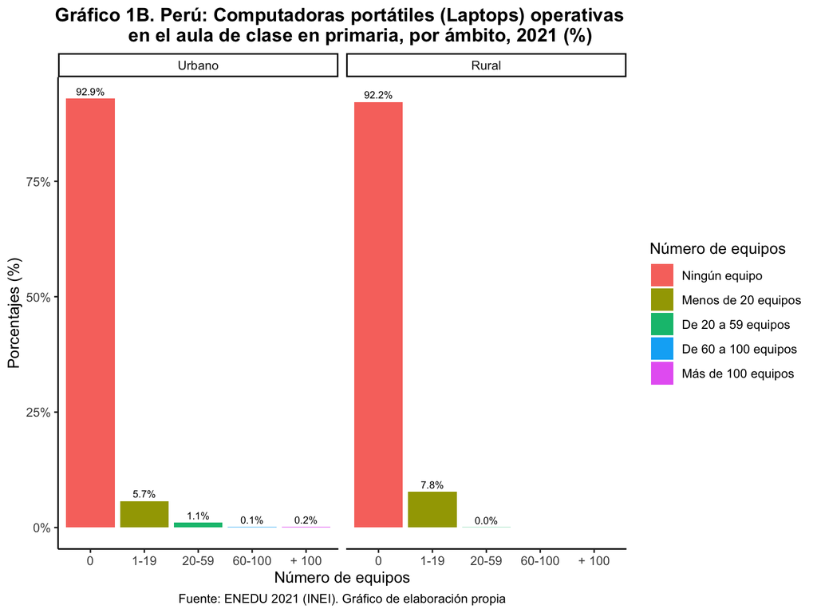

**Análisis:** En líneas generales, las estadísticas son similares entre ambas áreas. Por un lado, vemos que la categoría ‘Ningún equipo’ es la que mayor porcentaje de casos contiene tanto en área urbana como rural, con 92.9% y 92.2%, respectivamente. La segunda categoría con mayor porcentaje de casos es ‘Menos de 20 equipos’, con 5.7% en al área urbana y 7.8% en el área rural. En las demás categorías el área urbana supera ligeramente a la rural en porcentaje de equipos: en las categorías ‘De 20 a 59 equipos’ y ‘Más de 100 equipos’, mientras en el área rural hay 0% de casos, en el área urbana hay 1.1% y 0.2% respectivamente. De igual forma, son cifras mínimas comparadas al total. En conclusión, podríamos decir que si bien hay una escasez de equipos en general, puede ser en que en la educación primaria esta no sea tan relevante, y por ello hay cifras tan bajas en cuanto a número de equipos en el aula de clases. De todas formas, las cifras son alarmantes.

# 2A - Perú: Computadoras de escritorio (PC) para uso pedagógico en colegios de secundaria entre ámbito urbano y rural, 2021.

Tabla 2A. Perú: Computadoras de Escritorio (PC) para uso pedagógico en secundaria, por ámbito, 2021 (%)

| Número de equipos | Ámbito Urbano | Ámbito Rural |
| --- | --- | --- |
| Ningún equipo | 24.9 | 40.5 |
| Menos de 20 equipos | 32.2 | 39.2 |
| de 20 a 59 equipos | 34.5 | 19.9 |
| De 60 a 100 equipos | 6.4 | 0.4 |
| Más de 100 equipos | 2.0 | 0.0 |

* Fuente: ENEDU 2021 (INEI). Tabla de elaboración propia

# 2B - Perú: Computadoras portátiles (laptops) operativas en el aula de clases en colegios de secundaria entre el ámbito urbano y rural, 2021 (%).

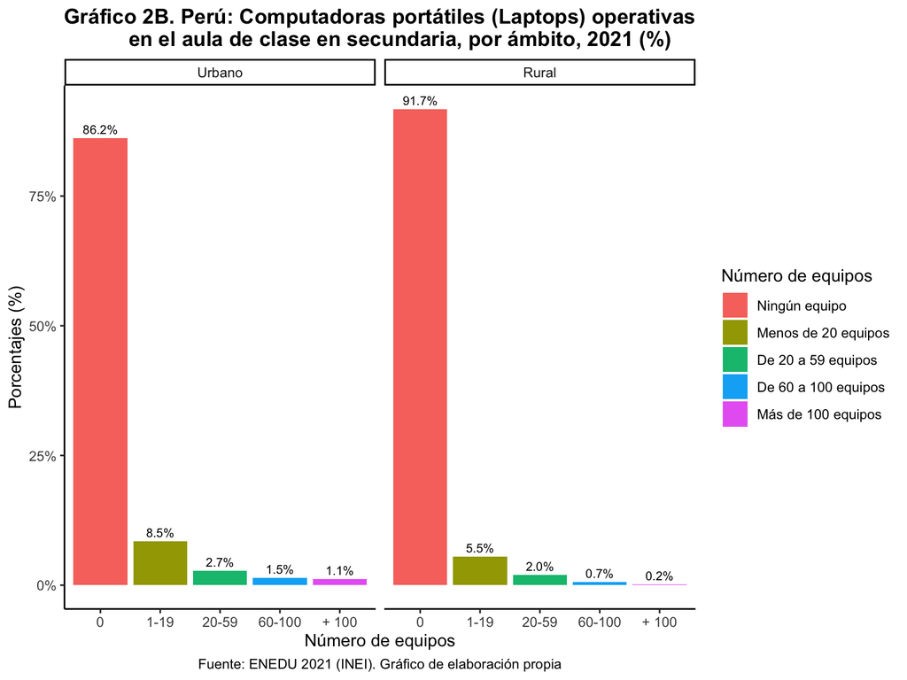

**Análisis:** En líneas generales, las estadísticas son relativamente similares entre ambas áreas. Por un lado, vemos que la categoría ‘Ningún equipo’ es la que mayor porcentaje de casos contiene tanta en área urbana como rural, con 86.2% y 91.7%, respectivamente; aquí hay una mayor diferencia entre áreas que en la tabla 1.b.. La segunda categoría con mayor porcentaje de casos es, nuevamente, ‘Menos de 20 equipos’, con 8.5% en al área urbana y 5.5% en el área rural. En todas las demás categorías el área urbana supera ligeramente a la rural en porcentaje de equipos: en las categorías ‘De 20 a 59 equipos’, ‘De 60 a 100 equipos’ y ‘Más de 100 equipos’, mientras en el área rural hay 2%, 0.7% y 0.2% de casos, en el área urbana hay 2.7%, 1.5% y 1.1%, respectivamente. Estos últimos datos son mínimos comparadas al total. En conclusión, podríamos decir que, si bien hay mayor porcentaje de escuelas con número de equipos, la situación es realmente precupante, pues la mayoría no cuenta equipos en el aula de clases.

# 3 - Perú: Tecnologías digitales para uso pedagógico de instituciones educativas entre el ámbito urbano y rural, 2021.

Tabla 3. Perú: Tecnologías digitales (TIC) para uso pedagógico con las que cuentan las instituciones educativas, por ámbito, 2021 (%)

| Número de equipos | Ámbito Urbano | Ámbito Rural |
| --- | --- | --- |
| Ningún equipo | 2.0 | 3.5 |
| Menos de 50 equipos | 18.8 | 12.1 |
| de 50 a 99 equipos | 17.8 | 22.5 |
| De 100 a 150 equipos | 15.9 | 16.0 |
| Más de 150 equipos | 45.4 | 45.9 |

* Fuente: ENEDU 2021 (INEI). Tabla de elaboración propia